# Lending_Club_Loan_Data_part_1(EDA)

## Lending Club Loan Data Analysis and Prediction

### Project Outlines:

#### 1. Define goal

```
a.Identify most important attributes separating bad loans and good loans
b.Build Xgboost model to make prediction
```

#### 2. EDA

```
a.Data first impression
  -available predicting variables
  -data distribution
  -missing values
b.Split dataset in to training and test set
c.correlation analysis and remove multicollinearity
d.Data Visualization to explore relationship between target and predicting variables
```

#### 3. Data Cleansing and Feature Engineering

```
a. Handling missing values
b. Transform any characteristics or categorical variables into numeric
c. Create new features from existing features
```

#### 4. Prepare dataset for modeling:

```
- Standard scale
- Handling Dataset imbalance issues (upsampling)
```

#### 5. Model Training and Evaluation

```
1). Logistic regression with L1 regularization model
2). Random Forest model
3). Xgboost model
    -hyperparameters Tuning
```

#### 6. Feature Selections Consideration

```
- Remove variables according to correlation analysis
- Logistic regression with L1 regularization (coeffecients not zero)
- Random Forest model built-in feature importance
```

#### 7. Assess any additional feature engineering or feature selection opportunity based on model results

#### 8. Choose the best model and evaluate prediction on test dataset

#### 9. Areas of improvements

### Part-1

The project is split into 3 notebooks. The notebook is part one, focusing on Data Exploratory Analysis

### Data Source

[Link to data](https://www.kaggle.com/wordsforthewise/lending-club)

```python
import re
import pickle
import pandas as pd
import numpy as np
import matplotlib
from matplotlib import pyplot as plt
import seaborn as sns
import os
import math
from sklearn.model_selection import train_test_split
from sklearn import metrics
from sklearn.linear_model import Ridge
from sklearn.linear_model import Lasso
matplotlib.rcParams.update({'font.size': 10})
import warnings
warnings.filterwarnings('ignore')
%config InlineBackend.figure_format = 'retina'
%matplotlib inline
from sklearn.linear_model import RidgeCV, ElasticNet, LassoCV, LassoLarsCV
from sklearn.model_selection import cross_val_score
from sklearn.preprocessing import StandardScaler
from sklearn.model_selection import train_test_split
from xgboost import XGBClassifier
from sklearn.model_selection import train_test_split
from sklearn.metrics import accuracy_score
from imblearn.over_sampling import SMOTENC
from sklearn.linear_model import LogisticRegression
from imblearn.over_sampling import RandomOverSampler
from imblearn.over_sampling import SMOTE
from sklearn.ensemble import RandomForestClassifier
import xgboost as xgb
from xgboost.sklearn import XGBClassifier
from sklearn.model_selection import GridSearchCV
from matplotlib.offsetbox import AnchoredText
from sklearn.metrics import classification_report
from sklearn.metrics import roc_auc_score
```

```python
# load data
data = pd.read_csv("./902_370089_bundle_archive/accepted_2007_to_2018q4.csv/accepted_2007_to_2018Q4.csv")
```

```python
data.shape
```

```
(2260701, 151)
```

```python
data.head()
```

|  | id | member_id | loan_amnt | funded_amnt | funded_amnt_inv | term | int_rate | installment | grade | sub_grade | ... | hardship_payoff_balance_amount | hardship_last_payment_amount | disbursement_method | debt_settlement_flag | debt_settlement_flag_date | settlement_status | settlement_date | settlement_amount | settlement_percentage | settlement_term |
| --- | --- | --- | --- | --- | --- | --- | --- | --- | --- | --- | --- | --- | --- | --- | --- | --- | --- | --- | --- | --- | --- |
| 0 | 68407277 | NaN | 3600.0 | 3600.0 | 3600.0 | 36 months | 13.99 | 123.03 | C | C4 | ... | NaN | NaN | Cash | N | NaN | NaN | NaN | NaN | NaN | NaN |
| 1 | 68355089 | NaN | 24700.0 | 24700.0 | 24700.0 | 36 months | 11.99 | 820.28 | C | C1 | ... | NaN | NaN | Cash | N | NaN | NaN | NaN | NaN | NaN | NaN |
| 2 | 68341763 | NaN | 20000.0 | 20000.0 | 20000.0 | 60 months | 10.78 | 432.66 | B | B4 | ... | NaN | NaN | Cash | N | NaN | NaN | NaN | NaN | NaN | NaN |
| 3 | 66310712 | NaN | 35000.0 | 35000.0 | 35000.0 | 60 months | 14.85 | 829.90 | C | C5 | ... | NaN | NaN | Cash | N | NaN | NaN | NaN | NaN | NaN | NaN |
| 4 | 68476807 | NaN | 10400.0 | 10400.0 | 10400.0 | 60 months | 22.45 | 289.91 | F | F1 | ... | NaN | NaN | Cash | N | NaN | NaN | NaN | NaN | NaN | NaN |

5 rows × 151 columns

```python
print(data.info(verbose =True, max_cols = True,null_counts=True))
```

```
<class 'pandas.core.frame.DataFrame'>
RangeIndex: 2260701 entries, 0 to 2260700
Data columns (total 151 columns):
id                                            2260701 non-null object
member_id                                     0 non-null float64
loan_amnt                                     2260668 non-null float64
funded_amnt                                   2260668 non-null float64
funded_amnt_inv                               2260668 non-null float64
term                                          2260668 non-null object
int_rate                                      2260668 non-null float64
installment                                   2260668 non-null float64
grade                                         2260668 non-null object
sub_grade                                     2260668 non-null object
emp_title                                     2093699 non-null object
emp_length                                    2113761 non-null object
home_ownership                                2260668 non-null object
annual_inc                                    2260664 non-null float64
verification_status                           2260668 non-null object
issue_d                                       2260668 non-null object
loan_status                                   2260668 non-null object
pymnt_plan                                    2260668 non-null object
url                                           2260668 non-null object
desc                                          126067 non-null object
purpose                                       2260668 non-null object
title                                         2237343 non-null object
zip_code                                      2260667 non-null object
addr_state                                    2260668 non-null object
dti                                           2258957 non-null float64
delinq_2yrs                                   2260639 non-null float64
earliest_cr_line                              2260639 non-null object
fico_range_low                                2260668 non-null float64
fico_range_high                               2260668 non-null float64
inq_last_6mths                                2260638 non-null float64
mths_since_last_delinq                        1102166 non-null float64
mths_since_last_record                        359156 non-null float64
open_acc                                      2260639 non-null float64
pub_rec                                       2260639 non-null float64
revol_bal                                     2260668 non-null float64
revol_util                                    2258866 non-null float64
total_acc                                     2260639 non-null float64
```

[output cut: 102 more lines]

```
hardship_loan_status                          10917 non-null object
orig_projected_additional_accrued_interest    8651 non-null float64
hardship_payoff_balance_amount                10917 non-null float64
hardship_last_payment_amount                  10917 non-null float64
disbursement_method                           2260668 non-null object
debt_settlement_flag                          2260668 non-null object
debt_settlement_flag_date                     34246 non-null object
settlement_status                             34246 non-null object
settlement_date                               34246 non-null object
settlement_amount                             34246 non-null float64
settlement_percentage                         34246 non-null float64
settlement_term                               34246 non-null float64
dtypes: float64(113), object(38)
memory usage: 2.5+ GB
None
```

```python
# Loading in the data dictionary
xls = pd.ExcelFile('LCDataDictionary.xlsx')
dict1 = pd.read_excel(xls, 'LoanStats')
dict2 = pd.read_excel(xls, 'browseNotes')
```

```python
# Column Names in the data dictionary
print(dict1.columns.tolist())
print(dict2.columns.tolist())
```

```
['LoanStatNew', 'Description']
['BrowseNotesFile', 'Description']
```

```python
dict1.loc[dict1['LoanStatNew'].isnull(),:]
```

|  | LoanStatNew | Description |
| --- | --- | --- |
| 151 | NaN | NaN |
| 152 | NaN | * Employer Title replaces Employer Name for al... |

```python
dict2.loc[dict2['BrowseNotesFile'].isnull(),:]
```

|  | BrowseNotesFile | Description |
| --- | --- | --- |
| 120 | NaN | NaN |
| 121 | NaN | * Employer Title replaces Employer Name for al... |

```python
# Remove NaN from data dictionary LoanStatNew
dict1.dropna(axis=0, subset=['LoanStatNew'], inplace= True)
```

```python
# Remove NaN from data dictionary LoanStatNew
dict2.dropna(axis=0, subset=['BrowseNotesFile'], inplace= True)
```

```python
print('Number of Features in LoanStatNew:' ,dict1.shape[0])
print('Number of Features in BrowseNotesFile:', dict2.shape[0])
```

```
Number of Features in LoanStatNew: 151
Number of Features in BrowseNotesFile: 120
```

```python
# available columns in data dictionary LoanStatNew
dict1['LoanStatNew'].tolist()
```

```
['acc_now_delinq',
 'acc_open_past_24mths',
 'addr_state',
 'all_util',
 'annual_inc',
 'annual_inc_joint',
 'application_type',
 'avg_cur_bal',
 'bc_open_to_buy',
 'bc_util',
 'chargeoff_within_12_mths',
 'collection_recovery_fee',
 'collections_12_mths_ex_med',
 'delinq_2yrs',
 'delinq_amnt',
 'desc',
 'dti',
 'dti_joint',
 'earliest_cr_line',
 'emp_length',
 'emp_title',
 'fico_range_high',
 'fico_range_low',
 'funded_amnt',
 'funded_amnt_inv',
 'grade',
 'home_ownership',
 'id',
 'il_util',
 'initial_list_status',
 'inq_fi',
 'inq_last_12m',
 'inq_last_6mths',
 'installment',
 'int_rate',
 'issue_d',
 'last_credit_pull_d',
 'last_fico_range_high',
 'last_fico_range_low',
 'last_pymnt_amnt',
```

[output cut: 96 more lines]

```
 'payment_plan_start_date',
 'hardship_length',
 'hardship_dpd',
 'hardship_loan_status',
 'orig_projected_additional_accrued_interest',
 'hardship_payoff_balance_amount',
 'hardship_last_payment_amount',
 'disbursement_method',
 'debt_settlement_flag',
 'debt_settlement_flag_date',
 'settlement_status',
 'settlement_date',
 'settlement_amount',
 'settlement_percentage',
 'settlement_term']
```

```python
# available columns in data dictionary LoanStatNew
dict2['BrowseNotesFile'].tolist()
```

```
['acceptD',
 'accNowDelinq',
 'accOpenPast24Mths',
 'addrState',
 'all_util',
 'annual_inc_joint',
 'annualInc',
 'application_type',
 'avg_cur_bal',
 'bcOpenToBuy',
 'bcUtil',
 'chargeoff_within_12_mths',
 'collections_12_mths_ex_med',
 'creditPullD',
 'delinq2Yrs',
 'delinqAmnt',
 'desc',
 'dti',
 'dti_joint',
 'earliestCrLine',
 'effective_int_rate',
 'emp_title',
 'empLength',
 'expD',
 'expDefaultRate',
 'ficoRangeHigh',
 'ficoRangeLow',
 'fundedAmnt',
 'grade',
 'homeOwnership',
 'id',
 'il_util',
 'ils_exp_d',
 'initialListStatus',
 'inq_fi',
 'inq_last_12m',
 'inqLast6Mths',
 'installment',
 'intRate',
 'isIncV',
```

[output cut: 65 more lines]

```
 'zip_code',
 'revol_bal_joint ',
 'sec_app_fico_range_low ',
 'sec_app_fico_range_high ',
 'sec_app_earliest_cr_line ',
 'sec_app_inq_last_6mths ',
 'sec_app_mort_acc ',
 'sec_app_open_acc ',
 'sec_app_revol_util ',
 'sec_app_open_act_il',
 'sec_app_num_rev_accts ',
 'sec_app_chargeoff_within_12_mths ',
 'sec_app_collections_12_mths_ex_med ',
 'sec_app_mths_since_last_major_derog ',
 'disbursement_method']
```

```python
#  All columns in the dataset
data.columns.tolist()
```

```
['id',
 'member_id',
 'loan_amnt',
 'funded_amnt',
 'funded_amnt_inv',
 'term',
 'int_rate',
 'installment',
 'grade',
 'sub_grade',
 'emp_title',
 'emp_length',
 'home_ownership',
 'annual_inc',
 'verification_status',
 'issue_d',
 'loan_status',
 'pymnt_plan',
 'url',
 'desc',
 'purpose',
 'title',
 'zip_code',
 'addr_state',
 'dti',
 'delinq_2yrs',
 'earliest_cr_line',
 'fico_range_low',
 'fico_range_high',
 'inq_last_6mths',
 'mths_since_last_delinq',
 'mths_since_last_record',
 'open_acc',
 'pub_rec',
 'revol_bal',
 'revol_util',
 'total_acc',
 'initial_list_status',
 'out_prncp',
 'out_prncp_inv',
```

[output cut: 96 more lines]

```
 'payment_plan_start_date',
 'hardship_length',
 'hardship_dpd',
 'hardship_loan_status',
 'orig_projected_additional_accrued_interest',
 'hardship_payoff_balance_amount',
 'hardship_last_payment_amount',
 'disbursement_method',
 'debt_settlement_flag',
 'debt_settlement_flag_date',
 'settlement_status',
 'settlement_date',
 'settlement_amount',
 'settlement_percentage',
 'settlement_term']
```

#### Data leakage in Machine Learning

What is data leakage in Machine Learning?

Some of your predictors (features/indepedent variables) that you are using in training your predictive models happen to have information about your target variables. [See more here](https://machinelearningmastery.com/data-leakage-machine-learning/).

Noted that some of the columns/features in the dataset are not available at the moment of investing until the loans have been issued. So these features should be removed, otherwise they would leek information from the future. We can use the variables that are in the data dictionary BrowseNoteFile, which lists only information available to investors when they are deciding whether to invest to any loans.

Noted that some features were named slightly different between the data dictionary sheet and the column names in the dataset but they referred to the same thing, so we will need to match the format between these column names.

```python
# Noted format differences between data dictionary BrowseNote and columns name in the dataset
index2 = [x not in dict2['BrowseNotesFile'].tolist() for x in data.columns.tolist()]
pd.Series(data.columns.tolist())[index2].head()
```

```
1          member_id
2          loan_amnt
3        funded_amnt
4    funded_amnt_inv
6           int_rate
dtype: object
```

```python
# Match the format of data dictionary to the columns names in the dataset
dictionary = dict2['BrowseNotesFile'].dropna().values
dictionary = [re.sub('(?<![0-9_])(?=[A-Z0-9])', '_', x).lower().strip() for x in dictionary]
```

```python
# Find features that are in dataset but not in the BrowseNote
index3 = [x not in dictionary for x in data.columns.tolist()]
pd.Series(data.columns.tolist())[index3].head()
```

```
4         funded_amnt_inv
14    verification_status
15                issue_d
16            loan_status
17             pymnt_plan
dtype: object
```

```python
# # The features that are in the BrowseNote but not in dataset
index4 = [x not in data.columns.tolist()for x in dictionary]
pd.Series(dictionary)[index4]
```

```
0                           accept_d
13                     credit_pull_d
20                effective_int_rate
23                             exp_d
24                  exp_default_rate
32                         ils_exp_d
39                          is_inc_v
40                            list_d
48                               msa
50         mths_since_oldest_il_open
54        mths_since_most_recent_inq
56     mths_since_recent_loan_delinq
84                     review_status
85                   review_status_d
88                  service_fee_rate
104            verified_status_joint
dtype: object
```

```python
# Manually match the spelling between column names in dataset and data dictionary 'BrowseNote'
uni_dict = ['is_inc_v','mths_since_oldest_il_open','mths_since_most_recent_inq',
             'mths_since_recent_loan_delinq','verified_status_joint']

uni_dataset = ['verification_status', 'mo_sin_old_il_acct','mths_since_recent_inq',
           'mths_since_recent_bc_dlq', 'verification_status_joint']


dictionary = np.setdiff1d(dictionary, uni_dict)
dictionary = np.append(dictionary,uni_dataset)
```

Create a list containing all features that are available in the dataset and also available to investors at the moment of investing

```python
dictionary = np.intersect1d(dictionary, data.columns.tolist())
```

```python
# Skim through the available features
dictionary
```

```
array(['acc_now_delinq', 'acc_open_past_24mths', 'addr_state', 'all_util',
       'annual_inc', 'annual_inc_joint', 'application_type',
       'avg_cur_bal', 'bc_open_to_buy', 'bc_util',
       'chargeoff_within_12_mths', 'collections_12_mths_ex_med',
       'delinq_2yrs', 'delinq_amnt', 'desc', 'disbursement_method', 'dti',
       'dti_joint', 'earliest_cr_line', 'emp_length', 'emp_title',
       'fico_range_high', 'fico_range_low', 'funded_amnt', 'grade',
       'home_ownership', 'id', 'il_util', 'initial_list_status', 'inq_fi',
       'inq_last_12m', 'inq_last_6mths', 'installment', 'int_rate',
       'loan_amnt', 'max_bal_bc', 'member_id', 'mo_sin_old_il_acct',
       'mo_sin_old_rev_tl_op', 'mo_sin_rcnt_rev_tl_op', 'mo_sin_rcnt_tl',
       'mort_acc', 'mths_since_last_delinq',
       'mths_since_last_major_derog', 'mths_since_last_record',
       'mths_since_rcnt_il', 'mths_since_recent_bc',
       'mths_since_recent_bc_dlq', 'mths_since_recent_inq',
       'mths_since_recent_revol_delinq', 'num_accts_ever_120_pd',
       'num_actv_bc_tl', 'num_actv_rev_tl', 'num_bc_sats', 'num_bc_tl',
       'num_il_tl', 'num_op_rev_tl', 'num_rev_accts',
       'num_rev_tl_bal_gt_0', 'num_sats', 'num_tl_120dpd_2m',
       'num_tl_30dpd', 'num_tl_90g_dpd_24m', 'num_tl_op_past_12m',
       'open_acc', 'open_acc_6m', 'open_act_il', 'open_il_12m',
       'open_il_24m', 'open_rv_12m', 'open_rv_24m', 'pct_tl_nvr_dlq',
       'percent_bc_gt_75', 'pub_rec', 'pub_rec_bankruptcies', 'purpose',
       'revol_bal', 'revol_bal_joint', 'revol_util',
       'sec_app_chargeoff_within_12_mths',
       'sec_app_collections_12_mths_ex_med', 'sec_app_earliest_cr_line',
       'sec_app_fico_range_high', 'sec_app_fico_range_low',
       'sec_app_inq_last_6mths', 'sec_app_mort_acc',
       'sec_app_mths_since_last_major_derog', 'sec_app_num_rev_accts',
       'sec_app_open_acc', 'sec_app_open_act_il', 'sec_app_revol_util',
       'sub_grade', 'tax_liens', 'term', 'title', 'tot_coll_amt',
       'tot_cur_bal', 'tot_hi_cred_lim', 'total_acc', 'total_bal_ex_mort',
       'total_bal_il', 'total_bc_limit', 'total_cu_tl',
       'total_il_high_credit_limit', 'total_rev_hi_lim', 'url',
       'verification_status', 'verification_status_joint', 'zip_code'],
      dtype='<U42')
```

Noted that Issue_d is the only column in the dataset that reveals when the loan was originated. Althought it's the date when the loan was issued (information from the future), we are going to extract the year and month of the issue date, which would represent the time period when investors were making investing decisions about that loans.

```python
# Adding back the target variable 'loan status' and 'issue_d' to the dictionary list
dictionary = np.append(dictionary, np.array(['loan_status', 'issue_d' ]))
```

```python
# Drop features that are not available at the moment of investing,except for loan_status(target variable)
cols_to_remove = [x not in dictionary for x in data.columns.tolist()]
cols_to_remove = pd.Series(data.columns.tolist())[cols_to_remove]
data.drop(columns=cols_to_remove, inplace = True)
```

Now we have a dataset with all features that are available to investors at the moment of investing after removing features that leeks information from the future.

```python
data.shape
```

```
(2260701, 111)
```

#### Check missing values in the target variable

```python
# Check if there is any missing values in the target variable, loan status
data.loan_status.isnull().sum()
```

```
33
```

```python
#Check data where loan status is NaN. Noted there is no loan information for any of these rows.
data.loc[data.loan_status.isnull(),:].head()
```

|  | id | member_id | loan_amnt | funded_amnt | term | int_rate | installment | grade | sub_grade | emp_title | ... | sec_app_inq_last_6mths | sec_app_mort_acc | sec_app_open_acc | sec_app_revol_util | sec_app_open_act_il | sec_app_num_rev_accts | sec_app_chargeoff_within_12_mths | sec_app_collections_12_mths_ex_med | sec_app_mths_since_last_major_derog | disbursement_method |
| --- | --- | --- | --- | --- | --- | --- | --- | --- | --- | --- | --- | --- | --- | --- | --- | --- | --- | --- | --- | --- | --- |
| 421095 | Total amount funded in policy code 1: 6417608175 | NaN | NaN | NaN | NaN | NaN | NaN | NaN | NaN | NaN | ... | NaN | NaN | NaN | NaN | NaN | NaN | NaN | NaN | NaN | NaN |
| 421096 | Total amount funded in policy code 2: 1944088810 | NaN | NaN | NaN | NaN | NaN | NaN | NaN | NaN | NaN | ... | NaN | NaN | NaN | NaN | NaN | NaN | NaN | NaN | NaN | NaN |
| 528961 | Total amount funded in policy code 1: 1741781700 | NaN | NaN | NaN | NaN | NaN | NaN | NaN | NaN | NaN | ... | NaN | NaN | NaN | NaN | NaN | NaN | NaN | NaN | NaN | NaN |
| 528962 | Total amount funded in policy code 2: 564202131 | NaN | NaN | NaN | NaN | NaN | NaN | NaN | NaN | NaN | ... | NaN | NaN | NaN | NaN | NaN | NaN | NaN | NaN | NaN | NaN |
| 651664 | Total amount funded in policy code 1: 1791201400 | NaN | NaN | NaN | NaN | NaN | NaN | NaN | NaN | NaN | ... | NaN | NaN | NaN | NaN | NaN | NaN | NaN | NaN | NaN | NaN |

5 rows × 111 columns

```python
# remove rows where loan status is missing
data.dropna(axis=0, subset=['loan_status'], inplace= True)
```

```python
# Let's check the distribution of target variable, loan status
data.loan_status.value_counts()
```

```
Fully Paid                                             1076751
Current                                                 878317
Charged Off                                             268559
Late (31-120 days)                                       21467
In Grace Period                                           8436
Late (16-30 days)                                         4349
Does not meet the credit policy. Status:Fully Paid        1988
Does not meet the credit policy. Status:Charged Off        761
Default                                                     40
Name: loan_status, dtype: int64
```

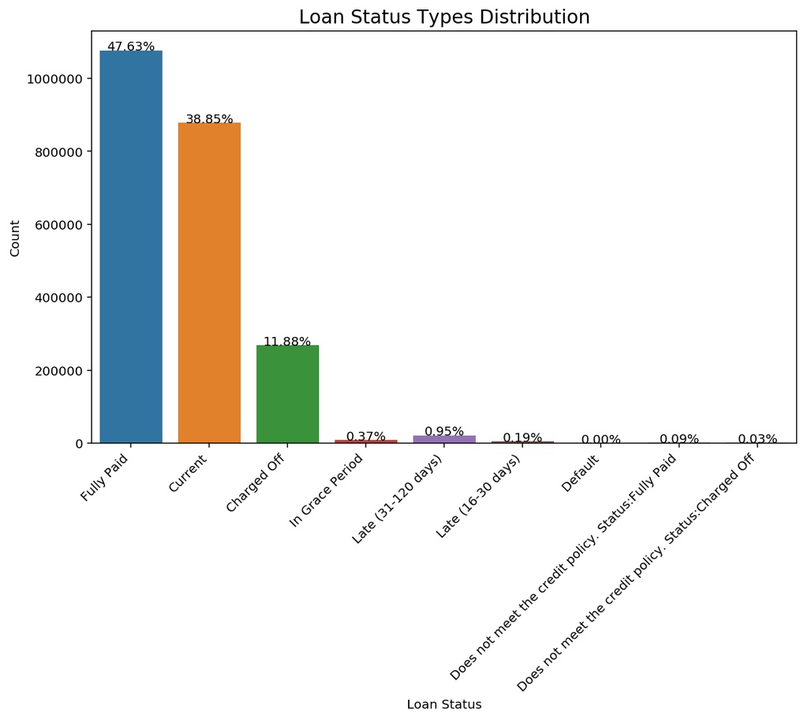

```python
# Loan status distribution
plt.figure(figsize = (10,6))
ax = sns.countplot(x="loan_status", data=data)
ax.set_xticklabels(ax.get_xticklabels(), rotation=45, horizontalalignment='right')
ax.set_xlabel("Loan Status", fontsize=10)
ax.set_ylabel("Count", fontsize=10)
ax.set_title("Loan Status Types Distribution", fontsize=15)
sizes=[]
for p in ax.patches:
    height = p.get_height()
    sizes.append(height)
    ax.text(p.get_x()+p.get_width()/2.,
            height + 4,
            '{:1.2%}'.format(height/len(data)),
            ha="center", fontsize=10)
```

### Re-define target variable (to be binary )

There are 9 loan statuses:

- Fully Paid
- Current,
- Charged Off
- In Grace Period
- Late (31-120 days)
- Late (16-30 days)
- Default
- Does not meet the credit policy. Status:Fully Paid,
- Does not meet the credit policy. Status:Charged Off

**We consider "Fully Paid", "Current", and "Does not meet the credit policy. Status:Fully Paid" as a good-condition loans and everything else as bad-condition loans.**

```python
# define bad_indicators
bad_indicators  =  ["Charged Off ",
                    "Charged Off",
                    "Default",
                    "Does not meet the credit policy. Status:Charged Off",
                    "In Grace Period",
                    "Default Receiver",
                    "Late (16-30 days)",
                    "Late (31-120 days)"]
```

```python
# Creat a new target variable
data['target'] = data['loan_status'].isin(bad_indicators).astype(int)
```

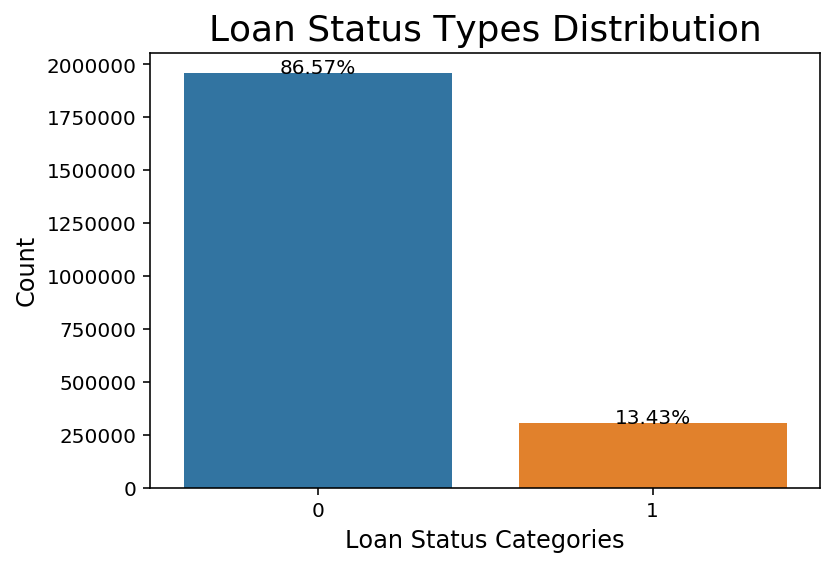

```python
# "Good" and "Bad" Loans Distribution
ax = sns.countplot(x="target", data=data)
ax.set_xlabel("Loan Status Categories", fontsize=12)
ax.set_ylabel("Count", fontsize=12)
ax.set_title("Loan Status Types Distribution", fontsize=18)

for p in ax.patches:
    height = p.get_height()
    ax.text(p.get_x()+p.get_width()/2.,
            height + 4,
            '{:1.2%}'.format(height/len(data)),
            ha="center", fontsize=10)
```

Noted the dataset is imbalanced with the minority group consisting of 13.43% of the population compared to the majarity group of 86.57%.

### Split Train Test Dataset

```python
y = data['target']

# Split the dataset into training and test dataset with random sampling
xtrain, xtest, ytrain, ytest = train_test_split(data, y, test_size=0.20,
                                                random_state=1, stratify=y)
```

```python
#Make sure the training and test set have similar distribution of majority and minority group
ytrain.mean()
```

```
0.13430214748520072
```

```python
ytest.mean()
```

```
0.13430089309806384
```

```python
# save train, test sets for later use
xtrain.to_csv("xtrain.csv", index=False)
xtest.to_csv("xtest.csv", index=False)
ytrain.to_csv("ytrain.csv", index=False)
ytest.to_csv("ytest.csv", index=False)
```

# EDA

#### Overview of Loans

Let's explore the data to see how features affect loan conditions. I will be focusing on the followings:

- loan amount vs funded amount
- Interest rate
- loans terms
- loan issue year
- Borrower's address (state)
- Borrower's Annual Income
- Borrower's Employment Length
- Loan Grade
- Home ownership
- Debt-to-income ratioo
- Loan Purpose

### Loan Amount vs Funded Amount

- Majority of the loan amount is between $10,000 to $20,000, with an average of $15,044.
- The distribution between loan amount and funded amount is quite similar, implying that for loans that passed approval, borrowers were highly likely to be funded with the desired amount

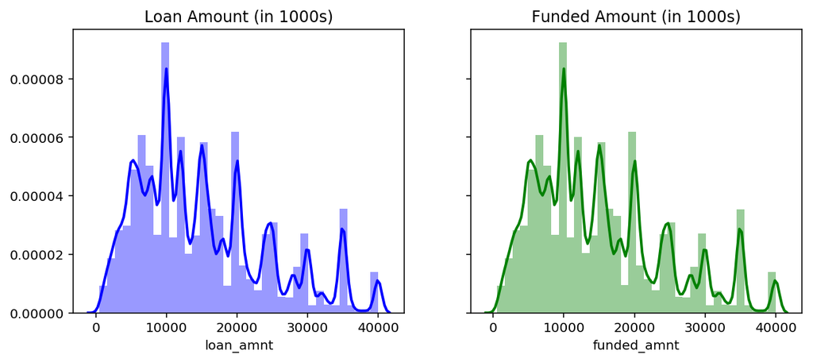

```
Loan Amount
Skewness: 0.777848
Kurtosis: -0.119390
Funded Amount
Skewness: 0.778844
Kurtosis: -0.116950
Average Loan Amount : 15044.23
```

```python
# Compare Loan Amount and Funded Amount
f, axes = plt.subplots(1, 2, figsize=(10, 4),  sharey=True)
sns.distplot(xtrain['loan_amnt'], hist=True, kde=True,
             bins=int(180/5),  color="b",
             kde_kws={'linewidth': 2}, ax = axes[0])
axes[0].set_title('Loan Amount (in 1000s)')
axes[0].set_xlabel('loan_amnt')


sns.distplot(xtrain['funded_amnt'], hist=True, kde=True,
             bins=int(180/5),  color="g",
             kde_kws={'linewidth': 2}, ax = axes[1])
axes[1].set_title('Funded Amount (in 1000s)')
axes[1].set_xlabel('funded_amnt')
plt.show()

print("Loan Amount")
print("Skewness: %f" % xtrain['loan_amnt'].skew())
print("Kurtosis: %f" % xtrain['loan_amnt'].kurt())

print("Funded Amount")
print("Skewness: %f" % xtrain['funded_amnt'].skew())
print("Kurtosis: %f" % xtrain['funded_amnt'].kurt())

print("Average Loan Amount : " + str(round(xtrain.loan_amnt.mean(),2)))
```

### Interest Rate

- Majority of interest rate is between 10% to 20%
- The average interest rate of good-condition loans (12.68%) is about 3% less than that of bad-condition loans (15.69%), implying that the higher interest rate (the higher monthly interest payment), the more likely that a loan defaults.

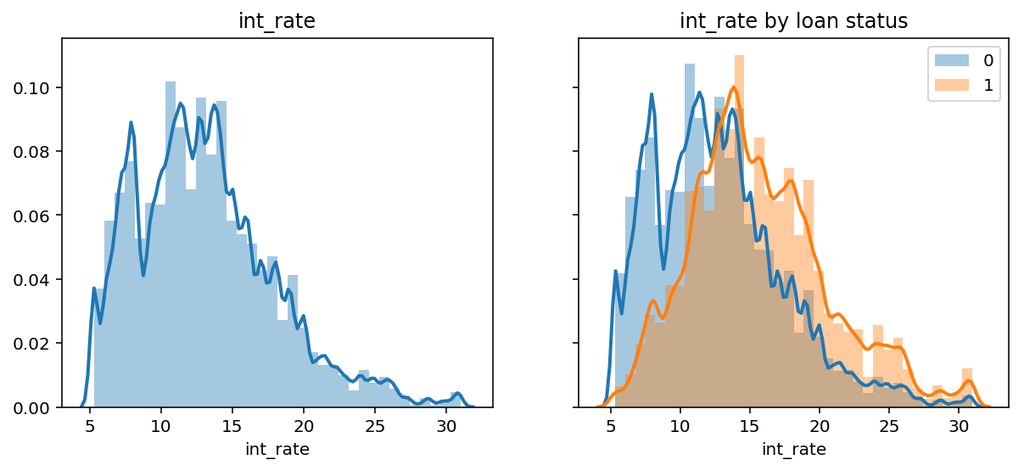

```
Skewness: 0.769178
Kurtosis: 0.597467
```

```python
# Check distribution of loan interest rate
f, axes = plt.subplots(1, 2, figsize=(10, 4),  sharey=True)


sns.distplot(xtrain['int_rate'], hist=True, kde=True,
             bins=int(180/5),
             kde_kws={'linewidth': 2},ax = axes[0])
axes[0].set_xlabel('int_rate')
axes[0].set_title('int_rate')



sns.distplot(xtrain.loc[xtrain['target']==0,'int_rate'], hist=True, kde=True,
             bins=int(180/5), label='0',
             kde_kws={'linewidth': 2},ax = axes[1])
sns.distplot(xtrain.loc[xtrain['target']==1,'int_rate'], hist=True, kde=True,
             bins=int(180/5),  label='1',
             kde_kws={'linewidth': 2},ax = axes[1])
axes[1].set_xlabel('int_rate')
axes[1].set_title('int_rate by loan status')



plt.legend()
plt.show()

print("Skewness: %f" % xtrain['int_rate'].skew())
print("Kurtosis: %f" % xtrain['int_rate'].kurt())
```

```python
print('Average Loan Interest Rate : ')
print('Good Loans:', xtrain.loc[xtrain['target']==0,'int_rate'].mean())
print('Bad Loans:', xtrain.loc[xtrain['target']==1,'int_rate'].mean())
```

```
Average Loan Interest Rate :
Good Loans: 12.689932877459434
Bad Loans: 15.694198443769201
```

**Based on the distribution plot and mean statistics, bad loans tend to have a high interest rate than good loans of lending club.**

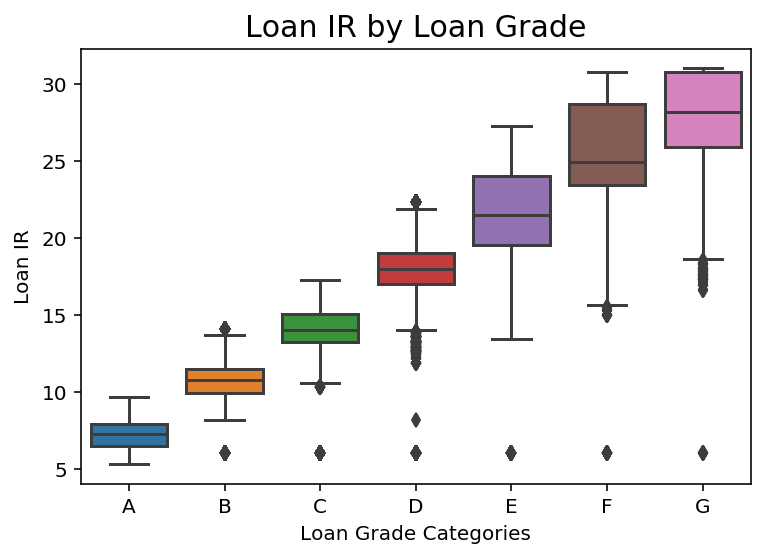

```python
# Loan interest rate by loan grade
ax = sns.boxplot(x="grade", y="int_rate", data=xtrain, order=["A","B","C","D","E","F","G"])

ax.set_xticklabels(ax.get_xticklabels())
ax.set_xlabel("Loan Grade Categories", fontsize=10)
ax.set_ylabel("Loan IR", fontsize=10)
ax.set_title("Loan IR by Loan Grade", fontsize=15)
plt.show()
```

The plots shows that the better grade of loans, the lower interest rate.

### Loans Terms

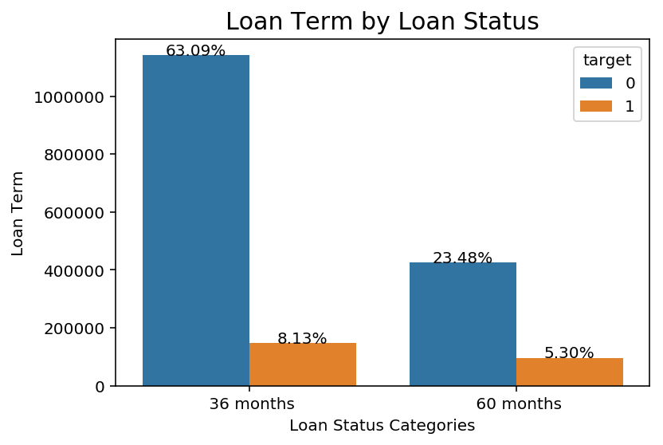

```python
# Loan term by loan status
ax = sns.countplot( x="term",   hue="target", data=xtrain)
ax.set_xticklabels(ax.get_xticklabels())
ax.set_xlabel("Loan Status Categories", fontsize=10)
ax.set_ylabel("Loan Term", fontsize=10)
ax.set_title("Loan Term by Loan Status", fontsize=15)

for p in ax.patches:
    height = p.get_height()
    ax.text(p.get_x()+p.get_width()/2.,
            height + 10,
            '{:1.2f}%'.format(height/len(xtrain)*100),
            ha="center", fontsize=10)
```

### Loan Issue Year

- From 2007 to 2018 number of loans issued every year is growing

```python
# Convert issue date to year and month separate variables
xtrain["issue_year"]= pd.to_datetime(xtrain.issue_d).dt.year
#xtrain['issue_y'] = pd.to_datetime(issue_d).dt.year.dropna().astype('int32')
```

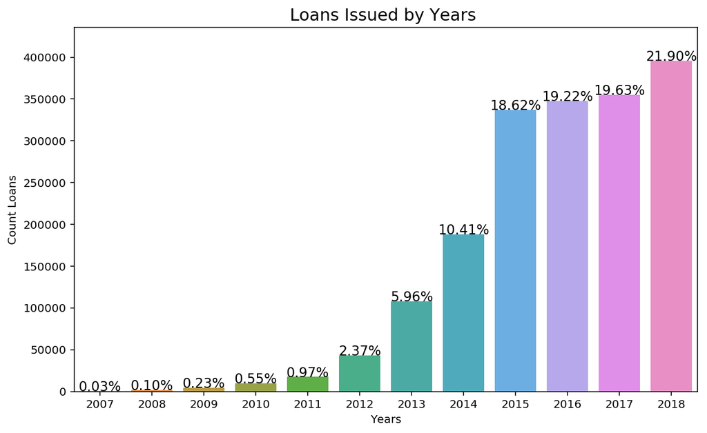

```python
#Total Loans by Years - Good vs Bad
plt.figure(figsize=(10,6))
ax = sns.countplot(x = 'issue_year', data=xtrain)
ax.set_xticklabels(ax.get_xticklabels())
ax.set_xlabel("Years", fontsize=10)
ax.set_ylabel("Count Loans", fontsize=10)
ax.set_title("Loans Issued by Years ", fontsize=15)
sizes=[]
for p in ax.patches:
    height = p.get_height()
    sizes.append(height)
    ax.text(p.get_x()+p.get_width()/2.,
            height + 10,
            '{:1.2f}%'.format(height/len(xtrain)*100),
            ha="center", fontsize=12)
ax.set_ylim(0, max(sizes) * 1.10)
plt.show()
```

#### Overview of Borrowers

Address (state)

Income

Average length of employment

Loan Grade

Home ownership

debt-to-income

Loan purpose

### Borrower's Address(states)

- Top 3 states in terms of number of loans issued: Califonia, New York and Texas
- Top 3 states in terms of percentage of issued loans that are in bad-condition: Iowa, Alabama, Arkansas

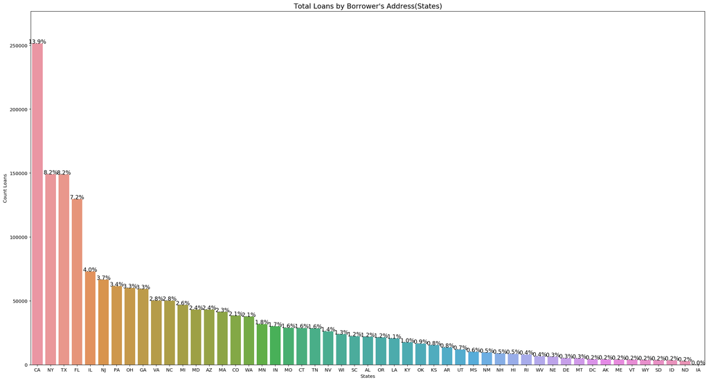

```python
#Total Loans by States - Good vs Bad
plt.figure(figsize=(26,14))
ax = sns.countplot(x='addr_state', data=xtrain,
                   order = xtrain['addr_state'].value_counts().index)

ax.set_xticklabels(ax.get_xticklabels())
ax.set_xlabel("States", fontsize=10)
ax.set_ylabel("Count Loans", fontsize=10)
ax.set_title("Total Loans by Borrower's Address(States)", fontsize=15)
sizes=[]
for p in ax.patches:
    height = p.get_height()
    sizes.append(height)
    ax.text(p.get_x()+p.get_width()/2.,
            height + 10,
            '{:1.1f}%'.format(height/len(xtrain)*100),
            ha="center", fontsize=12)
ax.set_ylim(0, max(sizes) * 1.10)
plt.show()
```

```python
# Count good and bad loans by state
state_df = xtrain.groupby(['addr_state', 'target']).size().reset_index().pivot(
    columns='target', index='addr_state', values=0).sort_values(by=1, ascending = False)
```

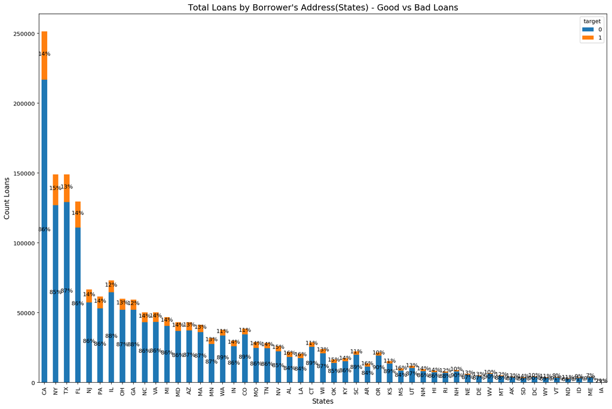

```python
#Total Loans by States - Good vs Bad

ax = state_df.plot.bar(stacked=True ,figsize= (18, 12))

#ax.set_xticklabels(ax.get_xticklabels())
ax.set_xlabel("States", fontsize=12)
ax.set_ylabel("Count Loans", fontsize=12)
ax.set_title("Total Loans by Borrower's Address(States) - Good vs Bad Loans", fontsize=15)
#sizes=[]


for i in range(51):
    p = ax.patches[i]
    width, height = p.get_width(), p.get_height()
    x, y = p.get_xy()
    ax.text(x + width/2.,
            y + height/2,
            '{:1.0f}%'.format(height/(height + ax.patches[i+51].get_height()) *100),
            ha="center", fontsize=10)

for i in range(51,102):
    p = ax.patches[i]
    width, height = p.get_width(), p.get_height()
    x, y = p.get_xy()
    ax.text(x + width/2.,
            y + height/2,
            '{:1.0f}%'.format(height/(height + ax.patches[i-51].get_height()) *100),
            ha="center", fontsize=10)
plt.show()
```

```python
state_df['default_rate'] =state_df[1]/(state_df[0]+state_df[1])
```

```python
# Top 10 states with the lowest average default rate
state_df.sort_values(by='default_rate').head(10)
```

| target addr_state | 0 | 1 | default_rate |
| --- | --- | --- | --- |
| ME | 3701 | 288 | 0.072199 |
| ID | 3138 | 308 | 0.089379 |
| VT | 3578 | 364 | 0.092339 |
| WV | 6028 | 651 | 0.097470 |
| NH | 8012 | 873 | 0.098255 |
| DC | 3894 | 426 | 0.098611 |
| OR | 19270 | 2139 | 0.099911 |
| SC | 19961 | 2393 | 0.107050 |
| CO | 34375 | 4125 | 0.107143 |
| ND | 2549 | 314 | 0.109675 |

```python
# Top 10 states with the highest average default rate
state_df.sort_values(by='default_rate', ascending = False).head(10)
```

| target addr_state | 0 | 1 | default_rate |
| --- | --- | --- | --- |
| IA | 11 | 3 | 0.214286 |
| AL | 18313 | 3546 | 0.162222 |
| AR | 11431 | 2155 | 0.158619 |
| MS | 8481 | 1591 | 0.157963 |
| LA | 17377 | 3246 | 0.157397 |
| OK | 14004 | 2538 | 0.153428 |
| NY | 126976 | 22138 | 0.148464 |
| NV | 22291 | 3883 | 0.148353 |
| FL | 110911 | 18781 | 0.144812 |
| HI | 7318 | 1238 | 0.144694 |

**Both the bar plots and summary table (default rate by state) show that some state have higher default rate than others.**

### Borrower's Annual Income

- The higher the income level of borrower, the less likely the loan turns into default.

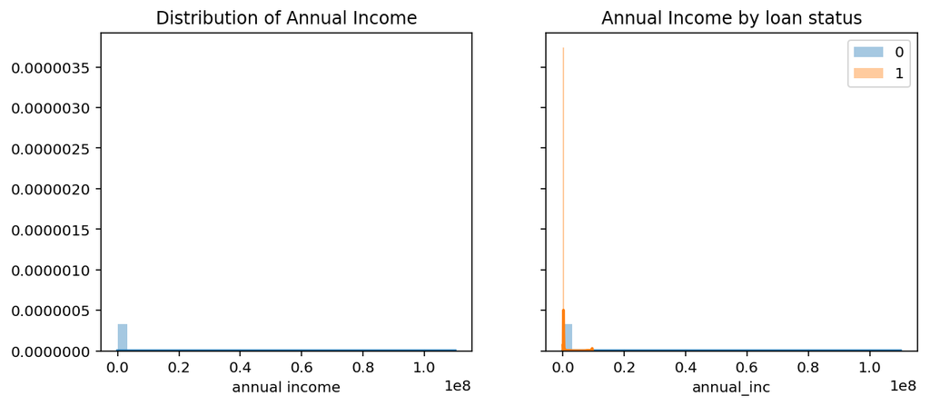

```
Skewness: 495.671570
Kurtosis: 411316.825794
```

```python
# Check distribution of Borrower's Annual Income
# These plots are not very understandable becuase of skewness and outliers
f, axes = plt.subplots(1, 2, figsize=(10, 4),  sharey=True)

sns.distplot(xtrain['annual_inc'], hist=True, kde=True, bins=int(180/5),
             kde_kws={'linewidth': 2},ax = axes[0])
axes[0].set_xlabel('annual income')
axes[0].set_title('Distribution of Annual Income')


sns.distplot(xtrain.loc[xtrain['target']==0,'annual_inc'], hist=True, kde=True,
             bins=int(180/5), label='0', kde_kws={'linewidth': 2},ax = axes[1])
sns.distplot(xtrain.loc[xtrain['target']==1,'annual_inc'], hist=True, kde=True,
             bins=int(180/5),  label='1', kde_kws={'linewidth': 2},ax = axes[1])
axes[1].set_xlabel('annual_inc')
axes[1].set_title('Annual Income by loan status')

plt.legend()
plt.show()

print("Skewness: %f" % xtrain['annual_inc'].skew())
print("Kurtosis: %f" % xtrain['annual_inc'].kurt())
```

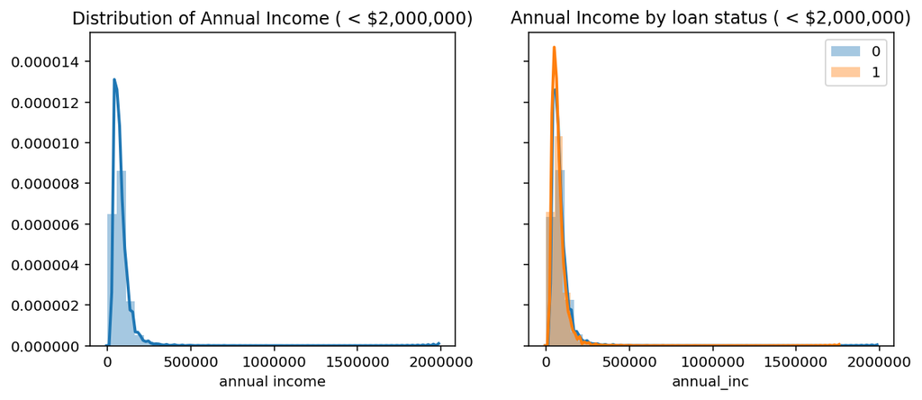

```
Skewness: 495.671570
Kurtosis: 411316.825794
```

```python
# Check distribution of Borrower's Annual Income, filtered for annual_inc < $2,000,000
f, axes = plt.subplots(1, 2, figsize=(10, 4),  sharey=True)

sns.distplot(xtrain.loc[xtrain['annual_inc'] < 2000000,'annual_inc'], hist=True, kde=True,
             bins=int(180/5), kde_kws={'linewidth': 2},ax = axes[0])
axes[0].set_xlabel('annual income')
axes[0].set_title('Distribution of Annual Income ( < $2,000,000)')

sns.distplot(xtrain.loc[(xtrain['target']==0) & (xtrain['annual_inc'] < 2000000),'annual_inc'], hist=True, kde=True,
             bins=int(180/5), label='0',kde_kws={'linewidth': 2},ax = axes[1])
sns.distplot(xtrain.loc[(xtrain['target']==1) & (xtrain['annual_inc'] < 2000000),'annual_inc'], hist=True, kde=True,
             bins=int(180/5),  label='1',kde_kws={'linewidth': 2},ax = axes[1])
axes[1].set_xlabel('annual_inc')
axes[1].set_title('Annual Income by loan status ( < $2,000,000)')

plt.legend()
plt.show()

print("Skewness: %f" % xtrain['annual_inc'].skew())
print("Kurtosis: %f" % xtrain['annual_inc'].kurt())
```

```python
print('Annual Income Quantiles:')
print("Low Income (below 25%): Annual_Inc <",  np.quantile(np.array(xtrain['annual_inc'].dropna()), 0.25) )
print("Median Income (between 25% and 75%):", np.quantile(np.array(xtrain['annual_inc'].dropna()), 0.25),
       "< Annual_Inc <",
     np.quantile(np.array(xtrain['annual_inc'].dropna()), 0.75))
print("High Income (above 75% below 95%): ", np.quantile(np.array(xtrain['annual_inc'].dropna()), 0.75),
       "< Annual_Inc <",
     np.quantile(np.array(xtrain['annual_inc'].dropna()), 0.95))
print("Extreme high income (Above 95%):  Annual_Inc >",
      np.quantile(np.array(xtrain['annual_inc'].dropna()), 0.95))
```

```
Annual Income Quantiles:
Low Income (below 25%): Annual_Inc < 46000.0
Median Income (between 25% and 75%): 46000.0 < Annual_Inc < 93000.0
High Income (above 75% below 95%):  93000.0 < Annual_Inc < 160000.0
Extreme high income (Above 95%):  Annual_Inc > 160000.0
```

```python
# Count good and bad loans by state
income_df = xtrain[['annual_inc', 'target']]
income_df.loc[income_df['annual_inc'] < 46000.0,'inc_cat'] = 'low_inc'
income_df.loc[(income_df['annual_inc'] >= 46000.0)
              & (income_df['annual_inc'] < 93000.0),'inc_cat'] = 'median_inc'
income_df.loc[(income_df['annual_inc'] >= 93000.0)
              & (income_df['annual_inc'] < 160000.0),'inc_cat'] = 'high_inc'
income_df.loc[income_df['annual_inc'] > 160000.0,'inc_cat'] = 'xhigh_inc'
```

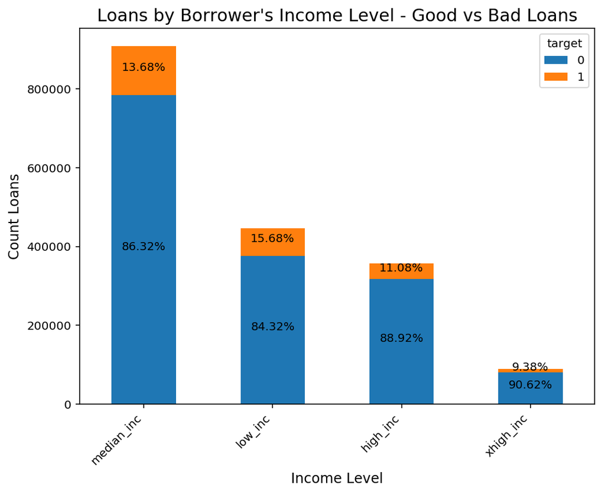

```python
#Good vs Bad Loans by Income Level
income_table = income_df.groupby(['inc_cat', 'target']).size().reset_index().pivot(
    columns='target', index='inc_cat', values=0).sort_values(by=1, ascending = False)
ax = income_table.plot.bar(stacked=True ,figsize= (8, 6))

ax.set_xticklabels(ax.get_xticklabels(), rotation=45, horizontalalignment='right')
ax.set_xlabel("Income Level", fontsize=12)
ax.set_ylabel("Count Loans", fontsize=12)
ax.set_title("Loans by Borrower's Income Level - Good vs Bad Loans", fontsize=15)
#sizes=[]

for i in range(4):
    p = ax.patches[i]
    width, height = p.get_width(), p.get_height()
    x, y = p.get_xy()
    ax.text(x + width/2.,
            y + height/2,
            '{:1.2f}%'.format(height/(height + ax.patches[i+4].get_height()) *100),
            ha="center", fontsize=10)

for i in range(4,8):
    p = ax.patches[i]
    width, height = p.get_width(), p.get_height()
    x, y = p.get_xy()
    ax.text(x + width/2.,
            y + height/2,
            '{:1.2f}%'.format(height/(height + ax.patches[i-4].get_height()) *100),
            ha="center", fontsize=10)
plt.show()
```

**We can see from the plot above, the higher the income level, the lower the loan default rate.**

### Borrower's employment length

- There is no clear pattern between loan default and employment length.

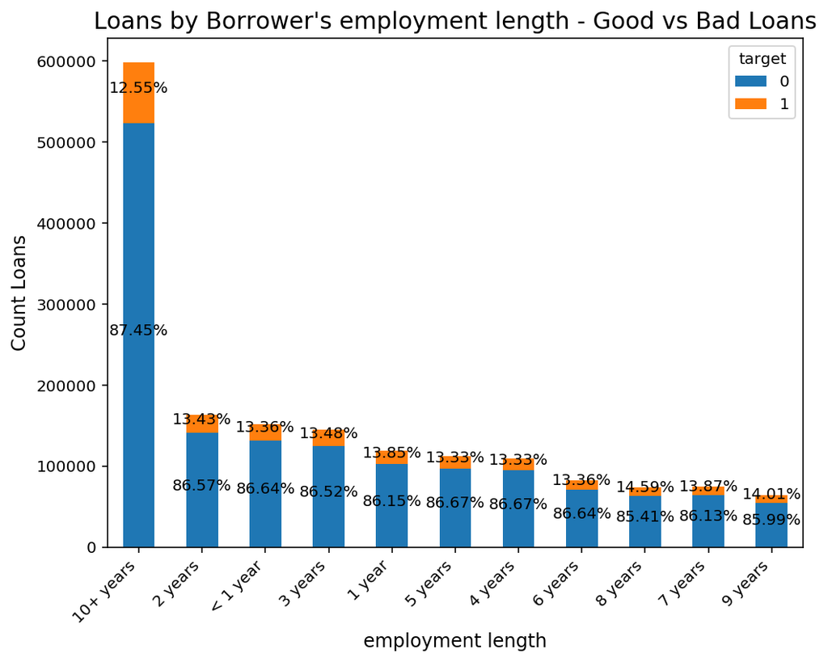

```python
#Good vs Bad Loans by emp_length
emp_length_table = xtrain.groupby(['emp_length', 'target']).size().reset_index().pivot(
    columns='target', index='emp_length', values=0).sort_values(by=1, ascending = False)
ax = emp_length_table.plot.bar(stacked=True ,figsize= (8, 6))

ax.set_xticklabels(ax.get_xticklabels(), rotation=45, horizontalalignment='right')
ax.set_xlabel("employment length", fontsize=12)
ax.set_ylabel("Count Loans", fontsize=12)
ax.set_title("Loans by Borrower's employment length - Good vs Bad Loans", fontsize=15)
#sizes=[]

n = len(ax.patches)
for i in range(int(n/2)):
    p = ax.patches[i]
    width, height = p.get_width(), p.get_height()
    x, y = p.get_xy()
    ax.text(x + width/2.,
            y + height/2,
            '{:1.2f}%'.format(height/(height + ax.patches[i+ int(n/2)].get_height()) *100),
            ha="center", fontsize=10)

for i in range(int(n/2),n):
    p = ax.patches[i]
    width, height = p.get_width(), p.get_height()
    x, y = p.get_xy()
    ax.text(x + width/2.,
            y + height/2,
            '{:1.2f}%'.format(height/(height + ax.patches[i- int(n/2)].get_height()) *100),
            ha="center", fontsize=10)
plt.show()
```

```python
# The employment length of largest two groups of borrowers
print('Percentage of borrowers ')
print('emp_length > 10+ ys: ', round((xtrain.emp_length.value_counts()/len(xtrain)).values[0],4))
print('emp_length <= 3 ys: ', round(sum((xtrain.emp_length.value_counts()/len(xtrain)).values[1:4]),4))
```

```
Percentage of borrowers
emp_length > 10+ ys:  0.3308
emp_length <= 3 ys:  0.2541
```

**There is no clear pattern between loan default and employment length. Noted that both people with long employment length(10+ years) and short employment length(<= 3 years) tend to borrow more.**

### Loan Grade

- The better the loan grade(Grade A as opposite to Grade G), the lower probability that a loan turns into bad-condition

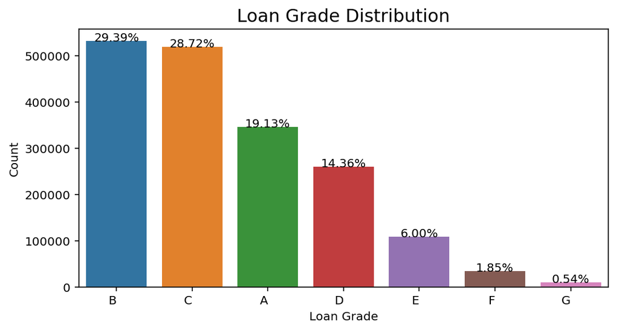

```python
# Loan grade distribution
plt.figure(figsize = (8,4))
ax = sns.countplot(x="grade", data=xtrain, order= xtrain.grade.value_counts().index)
ax.set_xticklabels(ax.get_xticklabels(),horizontalalignment='right')
ax.set_xlabel("Loan Grade", fontsize=10)
ax.set_ylabel("Count", fontsize=10)
ax.set_title("Loan Grade Distribution", fontsize=15)
sizes=[]
for p in ax.patches:
    height = p.get_height()
    sizes.append(height)
    ax.text(p.get_x()+p.get_width()/2.,
            height + 10,
            '{:1.2f}%'.format(height/len(xtrain)*100),
            ha="center", fontsize=10)
```

The majority of the loans are graded as A, B, C

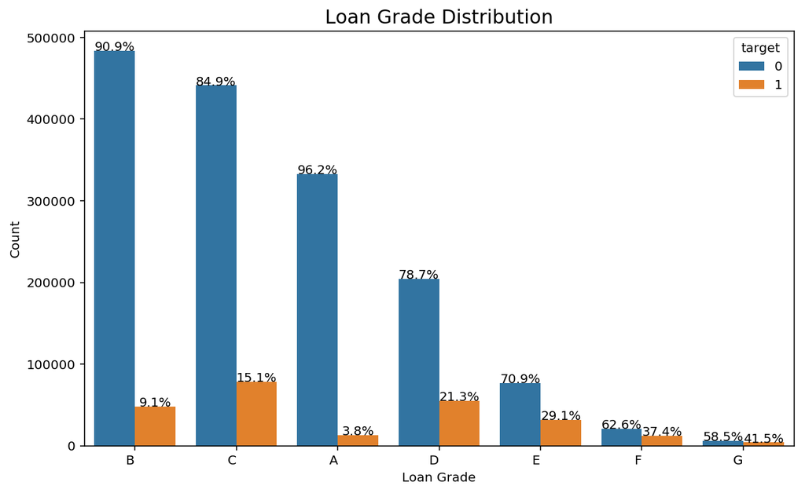

```python
#Loan Grade between 'good' and 'bad' loans
plt.figure(figsize = (10,6))
ax = sns.countplot(x="grade",hue="target", data=xtrain, order = xtrain.grade.value_counts().index)
ax.set_xticklabels(ax.get_xticklabels(),horizontalalignment='right')
ax.set_xlabel("Loan Grade", fontsize=10)
ax.set_ylabel("Count", fontsize=10)
ax.set_title("Loan Grade Distribution", fontsize=15)
sizes=[]
n = len(ax.patches)
for i in range(int(n/2)):
    p = ax.patches[i]
    width, height = p.get_width(), p.get_height()
    x, y = p.get_xy()
    ax.text(x + width/2.,
            y + height,
            '{:1.1f}%'.format(height/(height + ax.patches[i+ int(n/2)].get_height()) *100),
            ha="center", fontsize=10)

for i in range(int(n/2),n):
    p = ax.patches[i]
    width, height = p.get_width(), p.get_height()
    x, y = p.get_xy()
    ax.text(x + width/2.,
            y + height,
            '{:1.1f}%'.format(height/(height + ax.patches[i- int(n/2)].get_height()) *100),
            ha="center", fontsize=10)
plt.show()
```

**From the plot above, noted that the better the loan grade, the lower the "bad" loan ratios.**

### Home ownership

- It's unclear of the relationship between home ownership and bad-loans
- On average, 13.5% of home-owners in the dataset has turned a loan into default, while 15.6% of borrowers who rent has bad loans and 11.7% of mortage-holders has default loans.

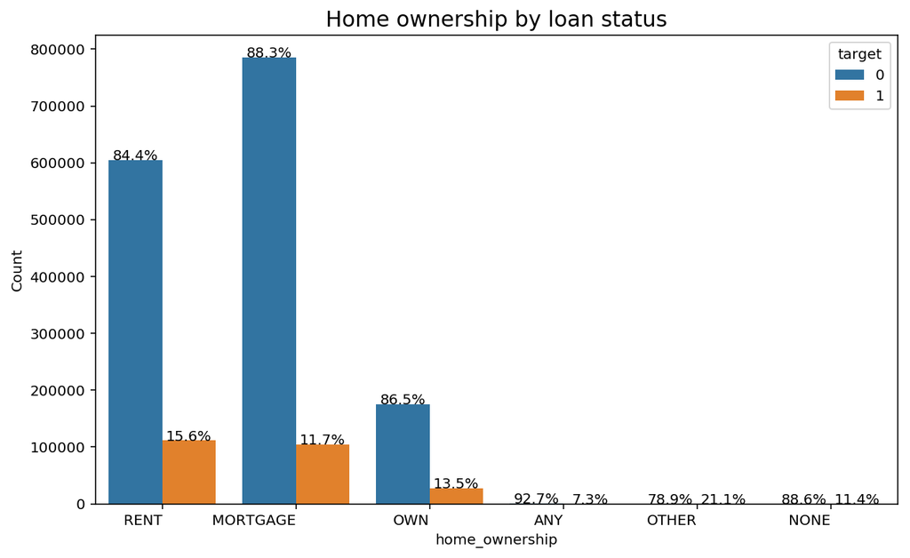

```python
#Homeownership and Loan Status
plt.figure(figsize = (10,6))
ax = sns.countplot(x="home_ownership",hue="target", data=xtrain)
ax.set_xticklabels(ax.get_xticklabels(),horizontalalignment='right')
ax.set_xlabel("home_ownership", fontsize=10)
ax.set_ylabel("Count", fontsize=10)
ax.set_title("Home ownership by loan status", fontsize=15)
sizes=[]
n = len(ax.patches)
for i in range(int(n/2)):
    p = ax.patches[i]
    width, height = p.get_width(), p.get_height()
    x, y = p.get_xy()
    ax.text(x + width/2.,
            y + height,
            '{:1.1f}%'.format(height/(height + ax.patches[i+ int(n/2)].get_height()) *100),
            ha="center", fontsize=10)

for i in range(int(n/2),n):
    p = ax.patches[i]
    width, height = p.get_width(), p.get_height()
    x, y = p.get_xy()
    ax.text(x + width/2.,
            y + height,
            '{:1.1f}%'.format(height/(height + ax.patches[i- int(n/2)].get_height()) *100),
            ha="center", fontsize=10)
plt.show()
```

### Debt-to-income

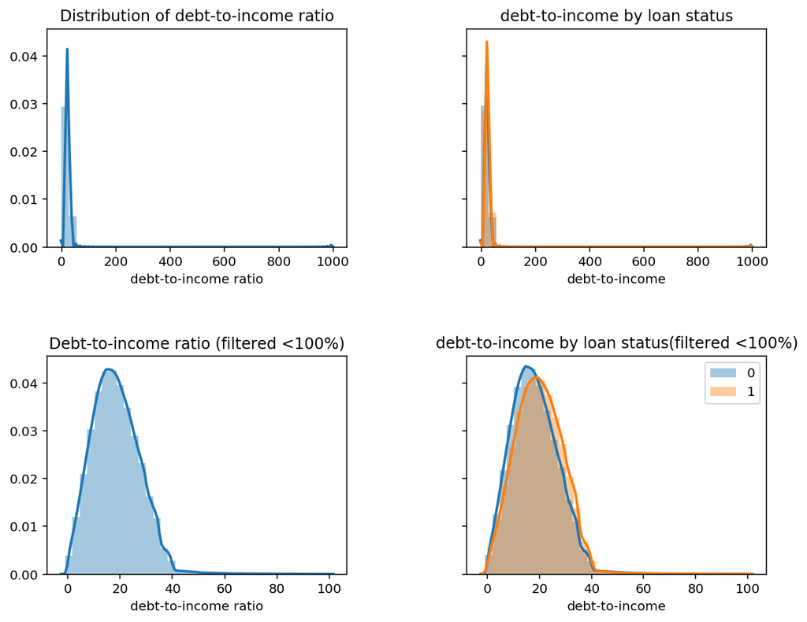

```
Skewness: 29.252373
Kurtosis: 1750.309492
```

```python
# Check distribution of loan interest rate
f, axes = plt.subplots(2, 2, figsize=(10, 6),  sharey=True)
plt.subplots_adjust(top = 0.99, bottom=0.01, hspace=0.5, wspace=0.4)
# Histogram 1 - debt-to-income ratio
sns.distplot(xtrain['dti'], hist=True, kde=True,
             bins=int(180/5),
             kde_kws={'linewidth': 2},ax = axes[0, 0])
axes[0,0].set_xlabel('debt-to-income ratio')
axes[0,0].set_title('Distribution of debt-to-income ratio')

# Histogram 2 - debt-to-income ratio between bad and good loans
sns.distplot(xtrain.loc[xtrain['target']==0,'dti'], hist=True, kde=True,
             bins=int(180/5), label='0',
             kde_kws={'linewidth': 2},ax = axes[0,1 ])
sns.distplot(xtrain.loc[xtrain['target']==1,'dti'], hist=True, kde=True,
             bins=int(180/5),  label='1',
             kde_kws={'linewidth': 2},ax = axes[0, 1])
axes[0,1].set_xlabel('debt-to-income')
axes[0,1].set_title('debt-to-income by loan status')

# Histogram 3 - debt to income ratio filtered for less-than-100-percent
sns.distplot(xtrain.loc[xtrain['dti']<100,"dti"], hist=True, kde=True,
             bins=int(180/5),
             kde_kws={'linewidth': 2},ax = axes[1,0])
axes[1,0].set_xlabel('debt-to-income ratio')
axes[1,0].set_title('Debt-to-income ratio (filtered <100%)')

#Histogram 4 - debt-to-income ratio between good and bad loans filtered for less-than-100-percent
sns.distplot(xtrain.loc[(xtrain['dti']<100) & (xtrain['target']==0),'dti'],
             hist=True, kde=True,
             bins=int(180/5), label='0',
             kde_kws={'linewidth': 2},ax = axes[1,1])
sns.distplot(xtrain.loc[(xtrain['dti']<100) & (xtrain['target']==1),'dti'],
            hist=True, kde=True,
             bins=int(180/5),  label='1',
             kde_kws={'linewidth': 2},ax = axes[1,1])
axes[1,1].set_xlabel('debt-to-income')
axes[1,1].set_title('debt-to-income by loan status(filtered <100%)')


plt.legend()
plt.show()

print("Skewness: %f" % xtrain['dti'].skew())
print("Kurtosis: %f" % xtrain['dti'].kurt())
```

```python
print("Debt-to-income ratio")
print("Good loans", xtrain.loc[xtrain['target']==0,'dti'].median())
print("Bad loans", xtrain.loc[xtrain['target']==1,'dti'].median())
```

```
Debt-to-income ratio
Good loans 17.56
Bad loans 19.65
```

Since the debt-to-income ratio is highly right skewed, I filtered for data with debt-to-income less than 100% to get a closer look to the majority of the data. The debt-to-income ratio has a distribution really close to a normal distribution between 0 and 40%. On average, the debt-to-income ratio is higher for the bad loans than the good loans.

```python
print('Debt-to-income(dti) Quantiles:')
print("Low dti (below 25%): dti <",  np.quantile(np.array(xtrain['dti'].dropna()), 0.25) )
print("Median dti (between 25% and 75%):", np.quantile(np.array(xtrain['dti'].dropna()), 0.25),
       "<= dti <",  np.quantile(np.array(xtrain['dti'].dropna()), 0.75))
print("High dti (above 75% below 95%): ", np.quantile(np.array(xtrain['dti'].dropna()), 0.75),
       "<= dti <", np.quantile(np.array(xtrain['dti'].dropna()), 0.95))
print("Extreme high dti (Above 95%): dti >",
      np.quantile(np.array(xtrain['dti'].dropna()), 0.95))
```

```
Debt-to-income(dti) Quantiles:
Low dti (below 25%): dti < 11.89
Median dti (between 25% and 75%): 11.89 <= dti < 24.48
High dti (above 75% below 95%):  24.48 <= dti < 33.88
Extreme high dti (Above 95%): dti > 33.88
```

```python
# Count good and bad loans by state
dti_df = xtrain[['dti', 'target']]
dti_df.loc[dti_df['dti'] < 11.89,'dti_cat'] = 'low'
dti_df.loc[(dti_df['dti'] >= 11.89)
              & (dti_df['dti'] < 24.48),'dti_cat'] = 'median'
dti_df.loc[(dti_df['dti'] >= 24.48)
              & (dti_df['dti'] < 33.88),'dti_cat'] = 'high'
dti_df.loc[dti_df['dti'] > 33.88,'dti_cat'] = 'xhigh'
```

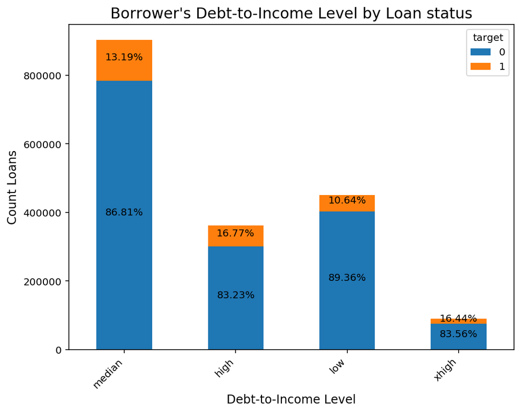

```python
#Good vs Bad Loans by Income Level
dti_table = dti_df.groupby(['dti_cat', 'target']).size().reset_index().pivot(
    columns='target', index='dti_cat', values=0).sort_values(by=1, ascending = False)
ax = dti_table.plot.bar(stacked=True ,figsize= (8, 6))

ax.set_xticklabels(ax.get_xticklabels(), rotation=45, horizontalalignment='right')
ax.set_xlabel("Debt-to-Income Level", fontsize=12)
ax.set_ylabel("Count Loans", fontsize=12)
ax.set_title("Borrower's Debt-to-Income Level by Loan status", fontsize=15)
#sizes=[]

for i in range(4):
    p = ax.patches[i]
    width, height = p.get_width(), p.get_height()
    x, y = p.get_xy()
    ax.text(x + width/2.,
            y + height/2,
            '{:1.2f}%'.format(height/(height + ax.patches[i+4].get_height()) *100),
            ha="center", fontsize=10)

for i in range(4,8):
    p = ax.patches[i]
    width, height = p.get_width(), p.get_height()
    x, y = p.get_xy()
    ax.text(x + width/2.,
            y + height/2,
            '{:1.2f}%'.format(height/(height + ax.patches[i-4].get_height()) *100),
            ha="center", fontsize=10)
plt.show()
```

Dividing loans into 4 groupbs based on borrowers' debt-to-income ratio:

- Low dti (below 25%): dti < 11.89
- Median dti (between 25% and 75%): 11.89 <= dti < 24.48
- High dti (above 75% below 95%): 24.48 <= dti < 33.88
- Extreme high dti (Above 95%): dti > 33.88

For high and extreme-high debt-to-income ratio groups, the percentage of loans that are in bad-condition(label = 1) is the highest, above 16%. The group of loans whose borrowers have median debt-to-income ratio has about 13% of chance of turning in bad loans. The borrowers has low debt-to-income ratio is least likely to bad loans (10.6%).

### Loan Purpose

- Top 3 reasons of people borrows on Lending club: Debt reconsolidation, Credit card payment and home improvement

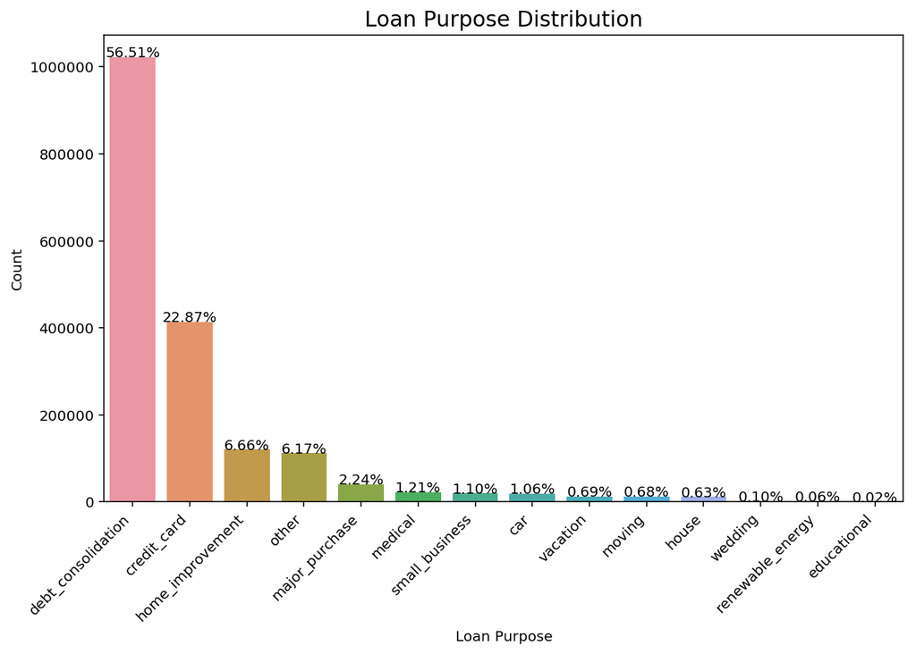

```python
# Loan purpose distribution
plt.figure(figsize = (10,6))
ax = sns.countplot(x="purpose", data=xtrain, order = xtrain.purpose.value_counts().index)
ax.set_xticklabels(ax.get_xticklabels(), rotation=45, horizontalalignment='right')
ax.set_xlabel("Loan Purpose", fontsize=10)
ax.set_ylabel("Count", fontsize=10)
ax.set_title("Loan Purpose Distribution", fontsize=15)
sizes=[]
for p in ax.patches:
    height = p.get_height()
    sizes.append(height)
    ax.text(p.get_x()+p.get_width()/2.,
            height + 10,
            '{:1.2f}%'.format(height/len(xtrain)*100),
            ha="center", fontsize=10)
```

**Noted that about 56% of the loans are used for debt_consolidation, 22.87% for credit card, and 6.66% for home_improvement**

## Colinearity

To detect colinearity among variables, we can simply create a correlation matrix and find variable pairs with large absolute values. However, multicolinearity is much harder to detect with this method as it involves more than 2 variables. Right now, we focus on identifying colinearity within the data. Later, we will apply Variance Inflation Factor (VIF) method to detect multicolinearity.

```python
# Separate numerica variables and categorical variables
cols = xtrain.columns.tolist()
num_cols = xtrain._get_numeric_data().columns.tolist()
cat_cols = [x for x in cols if x not in num_cols]
```

#### Correlation analysis with pearson method

```python
#  Correlation analysis with pearson method
xtrain_pcorr_matrix = xtrain[num_cols].corr(method="pearson")
```

```python
with open('xtrain_pcorr.pickle', 'wb') as f:
    pickle.dump(xtrain_pcorr_matrix, f)
# with open('xtrain_pcorr.pickle', 'rb') as f:
#     xtrain_pcorr_matrix = pickle.load(f)
```

```python
# High correlation with target variables using pearson method
pcorr_target = xtrain_pcorr_matrix["target"].abs().sort_values(kind="quicksort", ascending=False)
pcorr_target.head(12)
```

```
target                     1.000000
int_rate                   0.211981
sec_app_fico_range_low     0.138020
sec_app_fico_range_high    0.138019
fico_range_low             0.122275
fico_range_high            0.122273
issue_year                 0.116399
sec_app_inq_last_6mths     0.099210
acc_open_past_24mths       0.094778
inq_last_6mths             0.085028
num_tl_op_past_12m         0.083668
bc_open_to_buy             0.082026
Name: target, dtype: float64
```

```python
# Unstack covariance matrix pairs
xtrain_pcorr_sorted = xtrain_pcorr_matrix.abs().unstack().sort_values(kind="quicksort",
                                                                      ascending=False)
```

```python
# Table of variable pairs and correlation coefficients - pearson method
pcorr_df = pd.DataFrame([xtrain_pcorr_sorted[xtrain_pcorr_sorted != 1.0].drop_duplicates()]).T.reset_index()
# Sorted for highest correlated variable pairs
pcorr_df.head(10)
```

|  | level_0 | level_1 | 0 |
| --- | --- | --- | --- |
| 0 | sec_app_fico_range_high | sec_app_fico_range_low | 1.000000 |
| 1 | fico_range_low | fico_range_high | 1.000000 |
| 2 | funded_amnt | loan_amnt | 0.999757 |
| 3 | num_sats | open_acc | 0.998965 |
| 4 | num_actv_rev_tl | num_rev_tl_bal_gt_0 | 0.983665 |
| 5 | tot_hi_cred_lim | tot_cur_bal | 0.975460 |
| 6 | total_bal_il | total_il_high_credit_limit | 0.952008 |
| 7 | funded_amnt | installment | 0.945992 |
| 8 | installment | loan_amnt | 0.945652 |
| 9 | total_bal_ex_mort | total_bal_il | 0.898994 |

```python
# Create two lists, one with correlation higher than 0.7 , one with correlation higher than 0.9
# Compare the two variables in each high-correlation pairs, and choose the variable with the higher average correlations with all other variables within the dataset.
pcorr9_cols=set()
pcorr7_cols=set()
for i in range(len(pcorr_df)):
    if pcorr_df[0][i] >= 0.7:
        if xtrain_pcorr_matrix[pcorr_df.level_0[i]].abs().mean()> xtrain_pcorr_matrix[pcorr_df.level_1[i]].abs().mean():
            pcorr7_cols.add(pcorr_df.level_0[i])
        else :
            pcorr7_cols.add(pcorr_df.level_1[i])

    if pcorr_df[0][i] >= 0.9:
        if xtrain_pcorr_matrix[pcorr_df.level_0[i]].abs().mean()> xtrain_pcorr_matrix[pcorr_df.level_1[i]].abs().mean():
            pcorr9_cols.add(pcorr_df.level_0[i])
        else :
            pcorr9_cols.add(pcorr_df.level_1[i])
```

```python
# variables with corr >= 0.7
pcorr7_cols
```

```
{'acc_now_delinq',
 'acc_open_past_24mths',
 'annual_inc_joint',
 'bc_util',
 'fico_range_low',
 'funded_amnt',
 'loan_amnt',
 'mort_acc',
 'mths_since_last_delinq',
 'mths_since_recent_bc_dlq',
 'num_actv_rev_tl',
 'num_bc_sats',
 'num_op_rev_tl',
 'num_rev_accts',
 'num_rev_tl_bal_gt_0',
 'num_sats',
 'num_tl_op_past_12m',
 'open_acc',
 'open_il_24m',
 'open_rv_24m',
 'revol_util',
 'sec_app_fico_range_high',
 'sec_app_open_acc',
 'tot_cur_bal',
 'tot_hi_cred_lim',
 'total_acc',
 'total_bal_ex_mort',
 'total_bc_limit',
 'total_il_high_credit_limit',
 'total_rev_hi_lim'}
```

```python
# variables with corr >=0.9
pcorr9_cols
```

```
{'fico_range_low',
 'funded_amnt',
 'loan_amnt',
 'num_actv_rev_tl',
 'open_acc',
 'sec_app_fico_range_high',
 'tot_hi_cred_lim',
 'total_il_high_credit_limit'}
```

#### Correlation analysis with spearman method

```python
#  Correlation analysis with spearman method
xtrain_spcorr_matrix = xtrain[num_cols].corr(method="spearman")
xtrain_spcorr_sorted = xtrain_spcorr_matrix.abs().unstack().sort_values(kind="quicksort",
                                                                        ascending=False)
```

```python
# save the correlation matrix
with open('xtrain_spearcorr.pickle', 'wb') as f:
    pickle.dump([xtrain_spcorr_matrix, xtrain_spcorr_sorted], f)
```

```python
# with open('xtrain_pcorr.pickle', 'rb') as f:
#     xtrain_spcorr_matrix, xtrain_spcorr_sorted = pickle.load(f)
```

```python
# High correlation with target variables using spearman method
spcorr_target = xtrain_spcorr_matrix["target"].abs().sort_values(kind="quicksort",
                                                                 ascending=False)
spcorr_target.head(10)
```

```
target                     1.000000
int_rate                   0.210503
issue_year                 0.135719
sec_app_fico_range_high    0.131136
sec_app_fico_range_low     0.131136
fico_range_low             0.124864
fico_range_high            0.124864
bc_open_to_buy             0.096619
acc_open_past_24mths       0.095575
sec_app_inq_last_6mths     0.086528
Name: target, dtype: float64
```

```python
# Table of variable pairs and correlation coefficients - pearson method
spcorr_df = pd.DataFrame([xtrain_spcorr_sorted[xtrain_spcorr_sorted != 1.0].drop_duplicates()]).T.reset_index()
# Sorted for highest correlated variable pairs
spcorr_df.head(10)
```

|  | level_0 | level_1 | 0 |
| --- | --- | --- | --- |
| 0 | loan_amnt | funded_amnt | 0.999777 |
| 1 | num_sats | open_acc | 0.998739 |
| 2 | num_actv_rev_tl | num_rev_tl_bal_gt_0 | 0.991042 |
| 3 | tot_cur_bal | tot_hi_cred_lim | 0.972331 |
| 4 | installment | funded_amnt | 0.964788 |
| 5 | loan_amnt | installment | 0.964446 |
| 6 | total_il_high_credit_limit | total_bal_il | 0.956190 |
| 7 | tot_cur_bal | avg_cur_bal | 0.925816 |
| 8 | mths_since_recent_revol_delinq | mths_since_recent_bc_dlq | 0.886944 |
| 9 | total_bal_ex_mort | total_bal_il | 0.882222 |

```python
# Compare the two variables in each high-correlation pairs, and choose the variable with the higher average correlations with all other variables within the dataset.
spcorr7_cols=set()
for i in range(len(spcorr_df)):
    if spcorr_df[0][i]>=0.7:
        if xtrain_spcorr_matrix[spcorr_df.level_0[i]].abs().mean()> xtrain_spcorr_matrix[spcorr_df.level_1[i]].abs().mean():
            spcorr7_cols.add(spcorr_df.level_0[i])
        else :
            spcorr7_cols.add(spcorr_df.level_1[i])


spcorr9_cols=set()
for i in range(len(spcorr_df)):
    if spcorr_df[0][i]>=0.9:
        if xtrain_spcorr_matrix[spcorr_df.level_0[i]].abs().mean()> xtrain_spcorr_matrix[spcorr_df.level_1[i]].abs().mean():
            spcorr9_cols.add(spcorr_df.level_0[i])
        else :
            spcorr9_cols.add(spcorr_df.level_1[i])
```

```python
# variables with correlation coefficients >0.9 (spearman method)
spcorr9_cols
```

```
{'funded_amnt',
 'loan_amnt',
 'num_actv_rev_tl',
 'num_sats',
 'tot_cur_bal',
 'tot_hi_cred_lim',
 'total_bal_il'}
```

```python
# Combine the results of both pearson and spearman method (corr > 0.7)
corr7_vars = list(set(spcorr7_cols.union(pcorr7_cols)))
corr7_vars
```

```
['open_acc_6m',
 'mths_since_last_delinq',
 'num_sats',
 'num_tl_op_past_12m',
 'total_bal_il',
 'loan_amnt',
 'total_il_high_credit_limit',
 'annual_inc_joint',
 'fico_range_low',
 'open_acc',
 'bc_open_to_buy',
 'delinq_amnt',
 'delinq_2yrs',
 'num_actv_rev_tl',
 'open_il_24m',
 'sec_app_open_acc',
 'mort_acc',
 'mths_since_recent_bc_dlq',
 'tot_cur_bal',
 'bc_util',
 'acc_now_delinq',
 'acc_open_past_24mths',
 'num_bc_sats',
 'pub_rec',
 'num_il_tl',
 'num_rev_tl_bal_gt_0',
 'mo_sin_rcnt_rev_tl_op',
 'funded_amnt',
 'total_bc_limit',
 'sec_app_fico_range_high',
 'num_op_rev_tl',
 'mths_since_recent_revol_delinq',
 'total_rev_hi_lim',
 'total_acc',
 'open_rv_12m',
 'revol_bal',
 'mo_sin_rcnt_tl',
 'tot_hi_cred_lim',
 'open_rv_24m',
 'mths_since_rcnt_il',
 'num_rev_accts',
 'revol_util',
 'total_bal_ex_mort']
```

```python
# List of variables with correlation greater than 0.9(combining pearson and spearman method )
corr9_vars = list(set(spcorr9_cols.union(pcorr9_cols)))
corr9_vars
```

```
['num_sats',
 'tot_hi_cred_lim',
 'total_bal_il',
 'funded_amnt',
 'loan_amnt',
 'num_actv_rev_tl',
 'total_il_high_credit_limit',
 'sec_app_fico_range_high',
 'fico_range_low',
 'tot_cur_bal',
 'open_acc']
```

#### Dimension Reduction Consideration

Correlation analysis provides us a good start in understanding how closely variables are related to each other. Data redundancy exists when a dataset has variables that are highly correlated with other variables. We can do dimension reduction with the result from correlation analysis because it not only help us remove data redundancy, speed up processing time, but also reduce model complexity and prevent model overfitting issues. As we are going to investigate multicollinearity issue with Variance Inflation Factor (VIF) method, I am going to perform dimension reduction later by combining the result of both correlation analysis and Variance Inflation Factor analysis.

Pearson and Spearman correlation method only works for calculating correlation between the numeric varibles. For categorical variables, we can test if they are independent with Chi-Squared test of independence. For Categorical vs Numerical Variables, we can perform One-way ANOVA test by calculating in-group variance and intra-group variance and then compare them.